# wholesalecustomers

Tahani AlHarbi

11/19/2020

#### **Description:**

here I would analyze data about wholesales customers and answer some questions about annual spending of products in Horecia channel

#### **data:**

The dataset refers to clients of a wholesale distributor. It includes the annual spending in monetary units (m.u.) on diverse product categories channel 1 Horeca channel 2 Retail  
regions: Lisbon, Porto and other region

Attribute Information:

- **FRESH:** annual spending (m.u.) on fresh products (Continuous);
- **MILK:** annual spending (m.u.) on milk products (Continuous);
- **GROCERY:** annual spending (m.u.)on grocery products (Continuous);
- **FROZEN:** annual spending (m.u.)on frozen products (Continuous)
- **DETERGENTS_PAPER:** annual spending (m.u.) on detergents and products (Continuous)
- **DELICATESSEN:** annual spending (m.u.)on and delicatessen products (Continuous);
- **CHANNEL:** customers Channel - Horeca (Hotel/Restaurant/Cafe) or Retail channel (Nominal)
- **REGION:** customers Region Lisnon, Oporto or Other (Nominal)

#### **Packages**:

load tidyverse package

```r
#load packages
library(tidyverse)
```

### **Exploring Data:**

explore the wholesalecustomers data to get know data well

#### **Data head:**

```r
#Data head
knitr:: kable(head(wholesale_customers))
```

| Channel | Region | Fresh | Milk | Grocery | Frozen | Detergents_Paper | Delicassen |
| --- | --- | --- | --- | --- | --- | --- | --- |
| Retail | Other_Region | 12669 | 9656 | 7561 | 214 | 2674 | 1338 |
| Retail | Other_Region | 7057 | 9810 | 9568 | 1762 | 3293 | 1776 |
| Retail | Other_Region | 6353 | 8808 | 7684 | 2405 | 3516 | 7844 |
| Horeca | Other_Region | 13265 | 1196 | 4221 | 6404 | 507 | 1788 |
| Retail | Other_Region | 22615 | 5410 | 7198 | 3915 | 1777 | 5185 |
| Retail | Other_Region | 9413 | 8259 | 5126 | 666 | 1795 | 1451 |

#### **Data tail:**

```r
#Data tail
knitr::kable(tail(wholesale_customers))
```

|  | Channel | Region | Fresh | Milk | Grocery | Frozen | Detergents_Paper | Delicassen |
| --- | --- | --- | --- | --- | --- | --- | --- | --- |
| 435 | Horeca | Other_Region | 16731 | 3922 | 7994 | 688 | 2371 | 838 |
| 436 | Horeca | Other_Region | 29703 | 12051 | 16027 | 13135 | 182 | 2204 |
| 437 | Horeca | Other_Region | 39228 | 1431 | 764 | 4510 | 93 | 2346 |
| 438 | Retail | Other_Region | 14531 | 15488 | 30243 | 437 | 14841 | 1867 |
| 439 | Horeca | Other_Region | 10290 | 1981 | 2232 | 1038 | 168 | 2125 |
| 440 | Horeca | Other_Region | 2787 | 1698 | 2510 | 65 | 477 | 52 |

#### **see the proportion of 2 channels Horica and Retail in the Data:**

see the prportion of channels horica and Retail

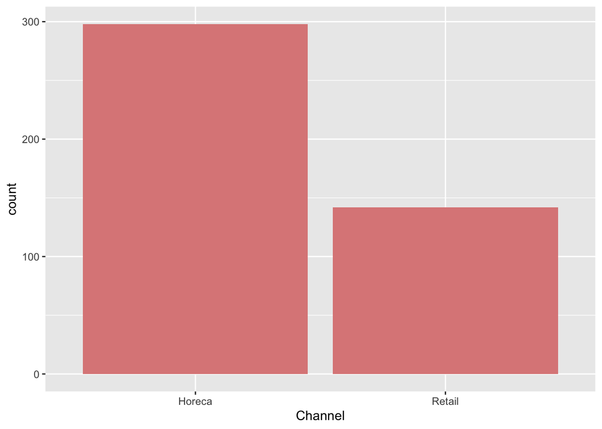

```r
#see the proportion of 2 channels  Horica and Retail in the Data
ggplot(wholesale_customers, aes(Channel)) +
  geom_bar(fill = "#DD8888")
```

#### **see the proportion of the Regions:**

also I want to see the proportion of regions

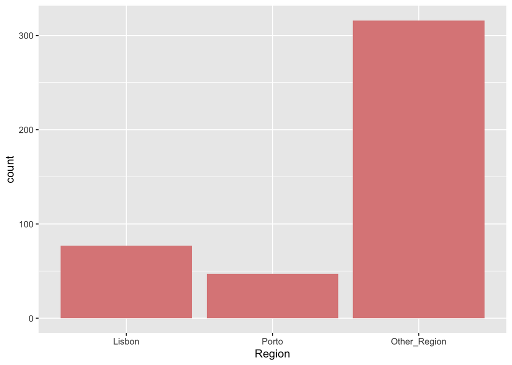

```r
#see the proportion of the Regions
ggplot(wholesale_customers,aes(Region))+ geom_bar(fill="#DD8888")
```

#### **See the max and min annual spending in the datat:**

max and min spending

```r
#See the max and min annual spending in the datat
wholesale_customers %>% summarise_if(is.numeric, max)
```

```
##    Fresh  Milk Grocery Frozen Detergents_Paper Delicassen
## 1 112151 73498   92780  60869            40827      47943
```

```r
wholesale_customers %>% summarise_if(is.numeric, min)
```

```
##   Fresh Milk Grocery Frozen Detergents_Paper Delicassen
## 1     3   55       3     25                3          3
```

#### **See the range of Milk annual spending:**

```r
#See the range of Milk annual spending
rangespendmilk <- wholesale_customers %>%
  summarise(range(Milk))

rangespendmilk
```

```
##   range(Milk)
## 1          55
## 2       73498
```

#### **See the range of Fresh annual spending:**

```r
#See the range of Fresh annual spending
rangespendfresh <- wholesale_customers %>%
  summarise(range(Fresh))

rangespendfresh
```

```
##   range(Fresh)
## 1            3
## 2       112151
```

#### **See the max and min spennd in Horeca Channel:**

```r
#See the max and min spennd in Horeca Channel

customer_horeca %>% summarise_if(is.numeric, max)
```

```
##    Fresh  Milk Grocery Frozen Detergents_Paper Delicassen
## 1 112151 43950   21042  60869             6907      47943
```

```r
customer_horeca %>% summarise_if(is.numeric, min)
```

```
##   Fresh Milk Grocery Frozen Detergents_Paper Delicassen
## 1     3   55       3     25                3          3
```

#### **See the max and min spend in Chanel Retail:**

```r
#See the max and min spend on Chanel Retail
customer_retail %>% summarise_if (is.numeric, max)
```

```
##   Fresh  Milk Grocery Frozen Detergents_Paper Delicassen
## 1 44466 73498   92780  11559            40827      16523
```

```r
customer_retail %>% summarise_if(is.numeric, min)
```

```
##   Fresh Milk Grocery Frozen Detergents_Paper Delicassen
## 1    18  928    2743     33              332          3
```

#### **see the annual spending on Milk:** see the annual spending on Milk product in 2 channels and 3 regions

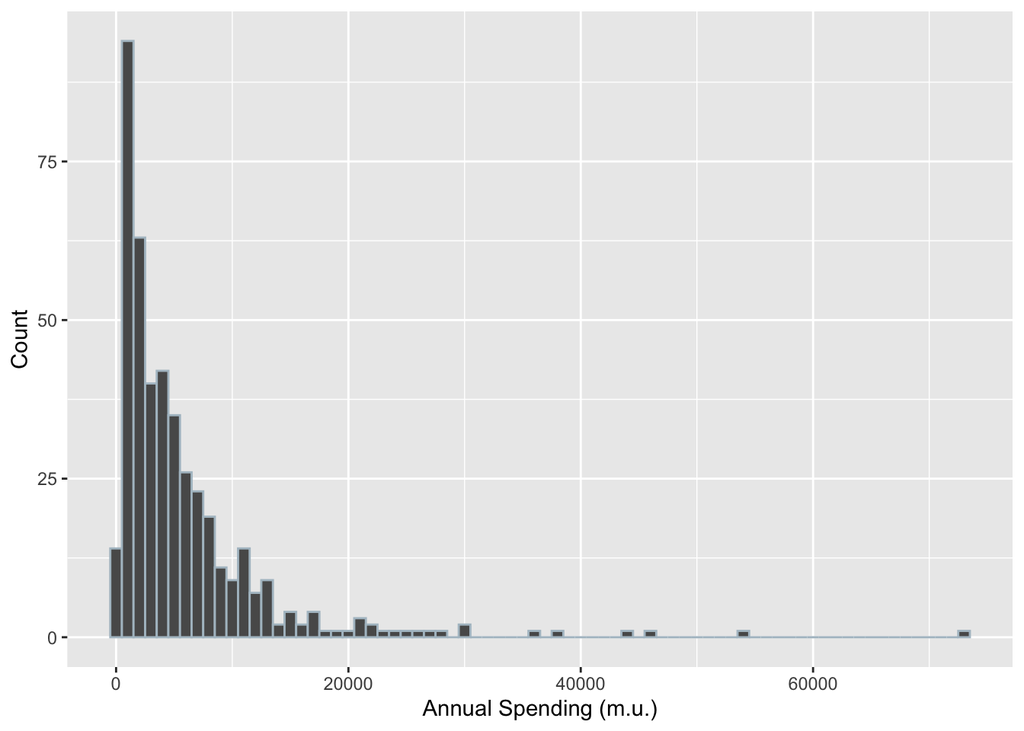

```r
#see the annual spending of Milk
ggplot(aes(x = Milk), data = wholesale_customers) +
  geom_histogram(binwidth = 1000,col="#AFC0CB") +
  xlab('Annual Spending (m.u.)') +
  ylab('Count')
```

#### **see the annual spending on Milk in Horeca channel:**

see the annual spending on Milk product in horica channel

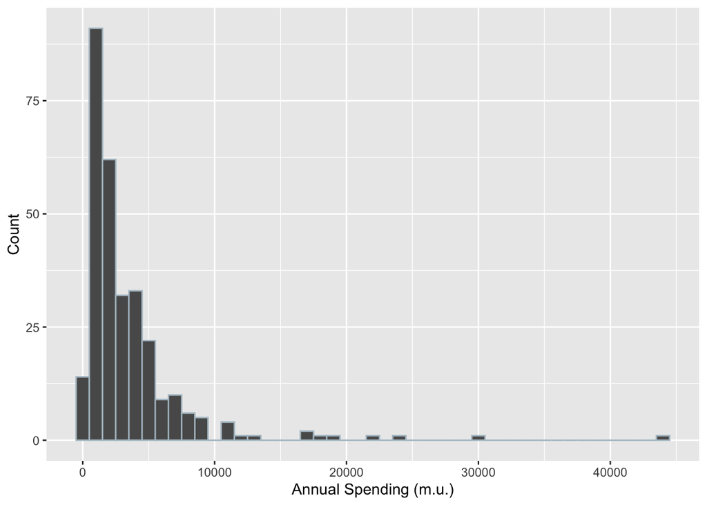

```r
#see the annual spending on Milk in Horeca channel
ggplot(aes(x = Milk), data = customer_horeca) +
  geom_histogram(binwidth = 1000,col="#AFC0CB") +
  xlab('Annual Spending (m.u.)') +
  ylab('Count')
```

#### **show the annual spending on products through channel Horeca:**

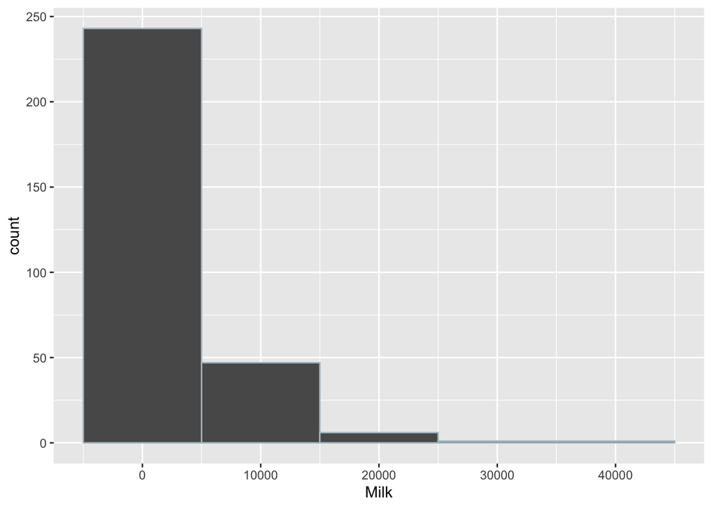

```r
#show the annual spending on products through channel Horeca
#Milk
ggplot( aes(x=Milk), data=customer_horeca)+geom_histogram(binwidth = 10000, col="#AFC0CB")
```

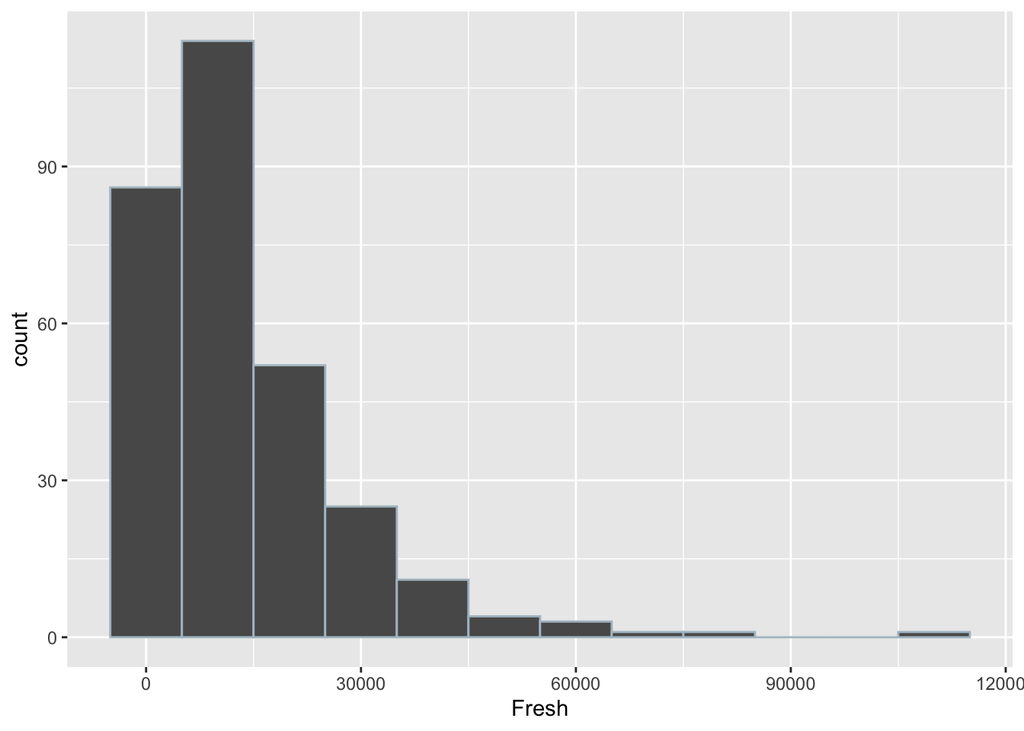

```r
#show the annual spending on products through channel Horeca
#Fresh
ggplot( aes(x=Fresh), data=customer_horeca)+geom_histogram(binwidth = 10000, col="#AFC0CB")
```

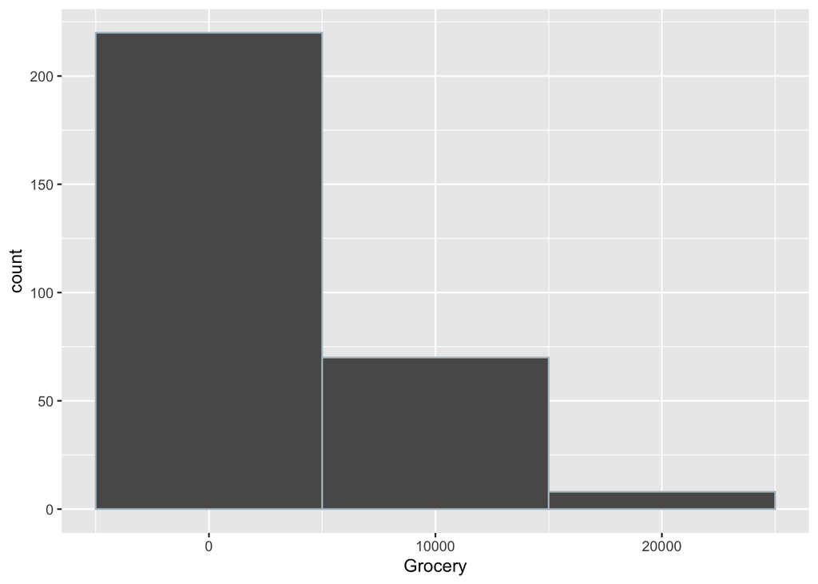

```r
#show the annual spending on products through channel Horeca
#Grosery
ggplot( aes(x=Grocery), data=customer_horeca)+geom_histogram(binwidth = 10000, col="#AFC0CB")
```

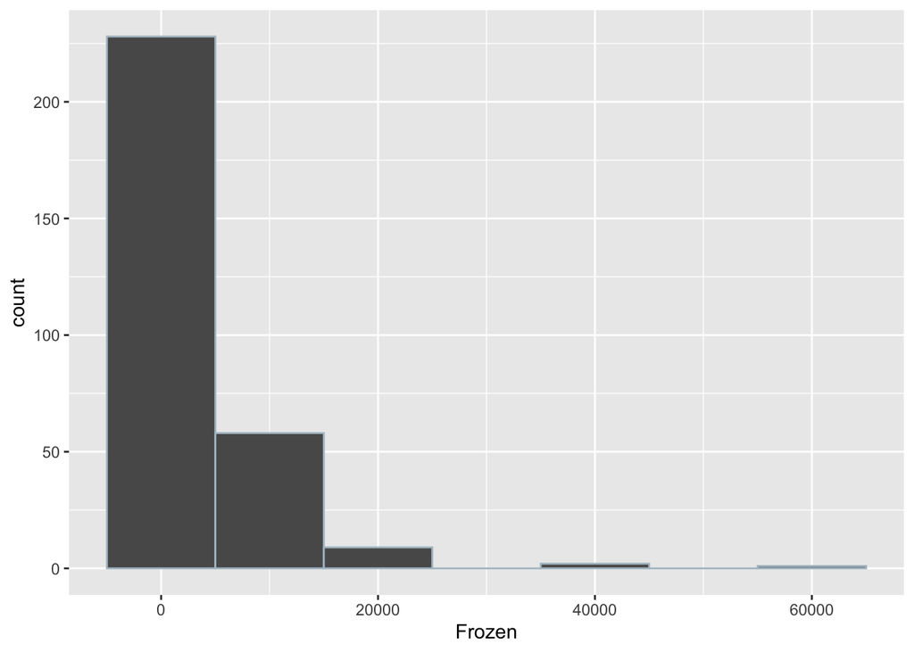

```r
#show the annual spending on products through channel Horeca
#Frozen
ggplot( aes(x=Frozen), data=customer_horeca)+geom_histogram(binwidth = 10000, col="#AFC0CB")
```

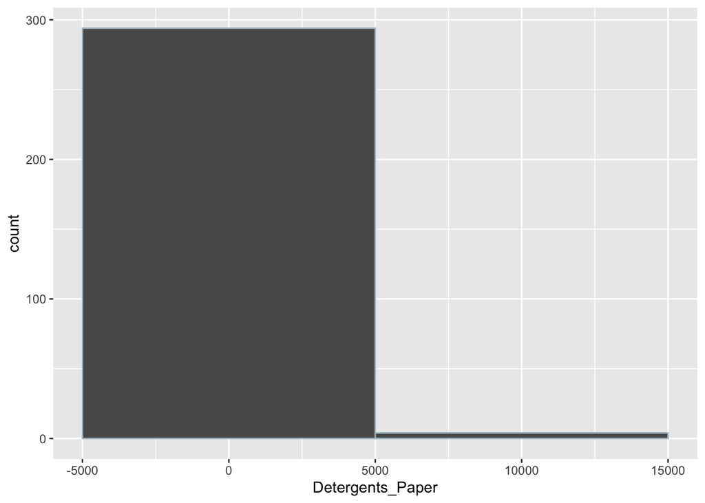

```r
#show the annual spending on products through channel Horeca
#Detergents_Paper
ggplot( aes(x=Detergents_Paper), data=customer_horeca)+geom_histogram(binwidth = 10000, col="#AFC0CB")
```

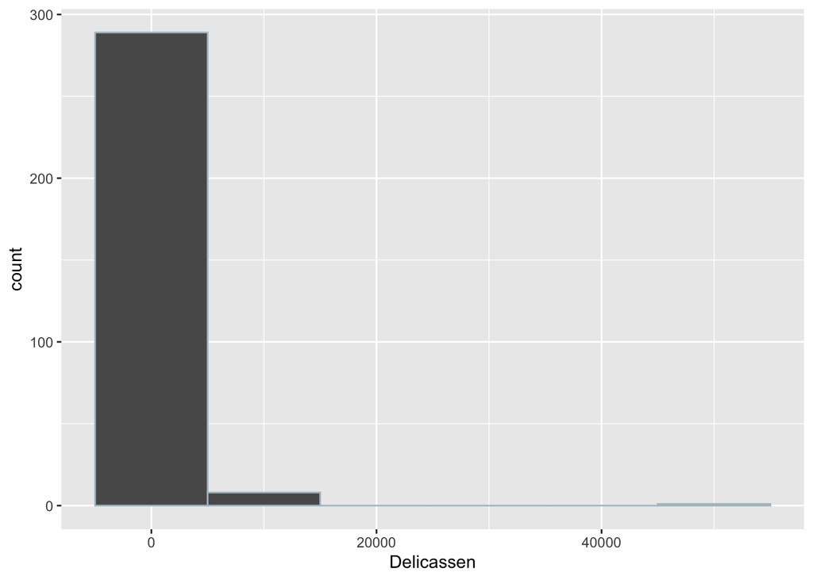

```r
#show the annual spending on products through channel Horeca
#Delicassen
ggplot( aes(x=Delicassen), data=customer_horeca)+geom_histogram(binwidth = 10000, col="#AFC0CB")
```